# Part I - (Prosper Loan data exploration and analysis.)

## Introduction

This data set contains 113,937 loans with 81 variables on each loan, including loan amount, borrower rate (or interest rate), current loan status, borrower income, and many others. Please find the data dictionary in the link below [data dictionary](https://docs.google.com/spreadsheets/d/1gDyi_L4UvIrLTEC6Wri5nbaMmkGmLQBk-Yx3z0XDEtI/edit#gid=0)

## Preliminary Wrangling

```python
# import all packages and set plots to be embedded inline
import numpy as np
import pandas as pd
import matplotlib.pyplot as plt
import seaborn as sb

%matplotlib inline
```

Loading data and assessing it

```python
df = pd.read_csv("prosperLoanData.csv")
```

```python
df.shape
```

```
(113937, 81)
```

```python
df.sample(10)
```

|  | ListingKey | ListingNumber | ListingCreationDate | CreditGrade | Term | LoanStatus | ClosedDate | BorrowerAPR | BorrowerRate | LenderYield | ... | LP_ServiceFees | LP_CollectionFees | LP_GrossPrincipalLoss | LP_NetPrincipalLoss | LP_NonPrincipalRecoverypayments | PercentFunded | Recommendations | InvestmentFromFriendsCount | InvestmentFromFriendsAmount | Investors |
| --- | --- | --- | --- | --- | --- | --- | --- | --- | --- | --- | --- | --- | --- | --- | --- | --- | --- | --- | --- | --- | --- |
| 47018 | A33F35317161657494B40A9 | 540850 | 2011-11-23 19:49:42.877000000 | NaN | 36 | Current | NaN | 0.29486 | 0.2561 | 0.2461 | ... | -47.92 | 0.0 | 0.00 | 0.00 | 0.0 | 1.0 | 0 | 0 | 0.0 | 13 |
| 94865 | 29313580728564951A237CB | 806389 | 2013-06-12 09:04:42.497000000 | NaN | 60 | Current | NaN | 0.11695 | 0.0949 | 0.0849 | ... | -96.00 | 0.0 | 0.00 | 0.00 | 0.0 | 1.0 | 0 | 0 | 0.0 | 236 |
| 25971 | C8C73594291269283D3916B | 1017155 | 2013-11-14 12:34:16.507000000 | NaN | 36 | Current | NaN | 0.23898 | 0.2015 | 0.1915 | ... | -9.88 | 0.0 | 0.00 | 0.00 | 0.0 | 1.0 | 0 | 0 | 0.0 | 1 |
| 607 | 00F43563947805596EC80E9 | 670164 | 2012-11-14 08:35:42.453000000 | NaN | 60 | Chargedoff | 2013-12-20 00:00:00 | 0.35097 | 0.3232 | 0.3132 | ... | -25.84 | 0.0 | 3753.61 | 3753.61 | 0.0 | 1.0 | 0 | 0 | 0.0 | 81 |
| 29261 | F83335380857287244947AF | 555872 | 2012-02-01 10:44:02.337000000 | NaN | 36 | Current | NaN | 0.24246 | 0.2049 | 0.1949 | ... | -44.96 | 0.0 | 0.00 | 0.00 | 0.0 | 1.0 | 0 | 0 | 0.0 | 1 |
| 91209 | 28D7347981162856163460C | 450600 | 2010-03-16 16:41:03.203000000 | NaN | 36 | Completed | 2013-03-12 00:00:00 | 0.07439 | 0.0710 | 0.0610 | ... | -39.81 | 0.0 | 0.00 | 0.00 | 0.0 | 1.0 | 0 | 1 | 50.0 | 119 |
| 21940 | 51E736038428197495A6718 | 1177741 | 2014-02-24 06:32:45.687000000 | NaN | 36 | Current | NaN | 0.16678 | 0.1305 | 0.1205 | ... | 0.00 | 0.0 | 0.00 | 0.00 | 0.0 | 1.0 | 0 | 0 | 0.0 | 1 |
| 102058 | 97CC356287396628384A1CF | 674014 | 2012-11-19 12:56:49.987000000 | NaN | 36 | Current | NaN | 0.09736 | 0.0839 | 0.0739 | ... | -25.73 | 0.0 | 0.00 | 0.00 | 0.0 | 1.0 | 0 | 0 | 0.0 | 55 |
| 24011 | EF163535899723526B826D6 | 550847 | 2012-01-11 18:16:33.047000000 | NaN | 36 | Current | NaN | 0.11766 | 0.0899 | 0.0799 | ... | -117.83 | 0.0 | 0.00 | 0.00 | 0.0 | 1.0 | 0 | 0 | 0.0 | 125 |
| 48269 | 536535854492047621EBAD2 | 847678 | 2013-07-22 13:34:56.820000000 | NaN | 60 | Current | NaN | 0.10367 | 0.0819 | 0.0719 | ... | -73.44 | 0.0 | 0.00 | 0.00 | 0.0 | 1.0 | 0 | 0 | 0.0 | 128 |

10 rows × 81 columns

```python
df.describe()
```

|  | ListingNumber | Term | BorrowerAPR | BorrowerRate | LenderYield | EstimatedEffectiveYield | EstimatedLoss | EstimatedReturn | ProsperRating (numeric) | ProsperScore | ... | LP_ServiceFees | LP_CollectionFees | LP_GrossPrincipalLoss | LP_NetPrincipalLoss | LP_NonPrincipalRecoverypayments | PercentFunded | Recommendations | InvestmentFromFriendsCount | InvestmentFromFriendsAmount | Investors |
| --- | --- | --- | --- | --- | --- | --- | --- | --- | --- | --- | --- | --- | --- | --- | --- | --- | --- | --- | --- | --- | --- |
| count | 1.139370e+05 | 113937.000000 | 113912.000000 | 113937.000000 | 113937.000000 | 84853.000000 | 84853.000000 | 84853.000000 | 84853.000000 | 84853.000000 | ... | 113937.000000 | 113937.000000 | 113937.000000 | 113937.000000 | 113937.000000 | 113937.000000 | 113937.000000 | 113937.000000 | 113937.000000 | 113937.000000 |
| mean | 6.278857e+05 | 40.830248 | 0.218828 | 0.192764 | 0.182701 | 0.168661 | 0.080306 | 0.096068 | 4.072243 | 5.950067 | ... | -54.725641 | -14.242698 | 700.446342 | 681.420499 | 25.142686 | 0.998584 | 0.048027 | 0.023460 | 16.550751 | 80.475228 |
| std | 3.280762e+05 | 10.436212 | 0.080364 | 0.074818 | 0.074516 | 0.068467 | 0.046764 | 0.030403 | 1.673227 | 2.376501 | ... | 60.675425 | 109.232758 | 2388.513831 | 2357.167068 | 275.657937 | 0.017919 | 0.332353 | 0.232412 | 294.545422 | 103.239020 |
| min | 4.000000e+00 | 12.000000 | 0.006530 | 0.000000 | -0.010000 | -0.182700 | 0.004900 | -0.182700 | 1.000000 | 1.000000 | ... | -664.870000 | -9274.750000 | -94.200000 | -954.550000 | 0.000000 | 0.700000 | 0.000000 | 0.000000 | 0.000000 | 1.000000 |
| 25% | 4.009190e+05 | 36.000000 | 0.156290 | 0.134000 | 0.124200 | 0.115670 | 0.042400 | 0.074080 | 3.000000 | 4.000000 | ... | -73.180000 | 0.000000 | 0.000000 | 0.000000 | 0.000000 | 1.000000 | 0.000000 | 0.000000 | 0.000000 | 2.000000 |
| 50% | 6.005540e+05 | 36.000000 | 0.209760 | 0.184000 | 0.173000 | 0.161500 | 0.072400 | 0.091700 | 4.000000 | 6.000000 | ... | -34.440000 | 0.000000 | 0.000000 | 0.000000 | 0.000000 | 1.000000 | 0.000000 | 0.000000 | 0.000000 | 44.000000 |
| 75% | 8.926340e+05 | 36.000000 | 0.283810 | 0.250000 | 0.240000 | 0.224300 | 0.112000 | 0.116600 | 5.000000 | 8.000000 | ... | -13.920000 | 0.000000 | 0.000000 | 0.000000 | 0.000000 | 1.000000 | 0.000000 | 0.000000 | 0.000000 | 115.000000 |
| max | 1.255725e+06 | 60.000000 | 0.512290 | 0.497500 | 0.492500 | 0.319900 | 0.366000 | 0.283700 | 7.000000 | 11.000000 | ... | 32.060000 | 0.000000 | 25000.000000 | 25000.000000 | 21117.900000 | 1.012500 | 39.000000 | 33.000000 | 25000.000000 | 1189.000000 |

8 rows × 61 columns

```python
df.info()
```

```
<class 'pandas.core.frame.DataFrame'>
RangeIndex: 113937 entries, 0 to 113936
Data columns (total 81 columns):
 #   Column                               Non-Null Count   Dtype
---  ------                               --------------   -----
 0   ListingKey                           113937 non-null  object
 1   ListingNumber                        113937 non-null  int64
 2   ListingCreationDate                  113937 non-null  object
 3   CreditGrade                          28953 non-null   object
 4   Term                                 113937 non-null  int64
 5   LoanStatus                           113937 non-null  object
 6   ClosedDate                           55089 non-null   object
 7   BorrowerAPR                          113912 non-null  float64
 8   BorrowerRate                         113937 non-null  float64
 9   LenderYield                          113937 non-null  float64
```

[output cut: 73 more lines]

### Data Cleaning

In this section I will doing some data cleaning, ie. checking the data types, the missing data, and removing columns that are not neccessary for our analysis etc.

#### Remove unwanted columns

Remove the columns that I will not use for my visualization and remain with the 17 coulmns that are described beow:

- `ListingCreationDate`: The date the listing was created.
- `Term`: The length of the loan expressed in months.
- `LoanStatus`: The current status of the loan: Cancelled, Chargedoff, Completed, Current, Defaulted, FinalPaymentInProgress, PastDue. The PastDue status will be accompanied by a delinquency bucket
- `BorrowerAPR`: The Borrower's Annual Percentage Rate (APR) for the loan.
- `BorrowerRate`: The Borrower's interest rate for this loan.
- `LenderYield`: The Lender yield on the loan. Lender yield is equal to the interest rate on the loan less the servicing fee.
- `ListingCategory`: The category of the listing that the borrower selected when posting their listing: 0 - Not Available, 1 - Debt Consolidation, 2 - Home Improvement, 3 - Business, 4 - Personal Loan, 5 - Student Use, 6 - Auto, 7- Other, 8 - Baby&Adoption, 9 - Boat, 10 - Cosmetic Procedure, 11 - Engagement Ring, 12 - Green Loans, 13 - Household Expenses, 14 - Large Purchases, 15 - Medical/Dental, 16 - Motorcycle, 17 - RV, 18 - Taxes, 19 - Vacation, 20 - Wedding Loans.
- `EmploymentStatus`: The employment status of the borrower at the time they posted the listing.
- `EmploymentStatusDuration`: The length in months of the employment status at the time the listing was created.
- `IsBorrowerHomeowner`: A Borrower will be classified as a homowner if they have a mortgage on their credit profile or provide documentation confirming they are a homeowner.
- `IncomeRange`: The income range of the borrower at the time the listing was created.
- `IncomeVerifiable`: The borrower indicated they have the required documentation to support their income.
- `StatedMonthlyIncome`: The monthly income the borrower stated at the time the listing was created.
- `LoanOriginalAmount`: The origination amount of the loan.
- `LoanOriginationDate`: The date the loan was originated.
- `LoanOriginationQuarter`: The quarter in which the loan was originated.
- `MonthlyLoanPayment`: The scheduled monthly loan payment.

```python
# df1 = df.iloc[:,[2,4,5,7,8,9,16,19,20,21,47,48,49,50,51,52,63,64,65,67,80]]
df1 = df.iloc[:,[2,4,5,7,8,9,16,19,20,21,47,48,49,63,64,65,67]]
df1.head(10)
```

|  | ListingCreationDate | Term | LoanStatus | BorrowerAPR | BorrowerRate | LenderYield | ListingCategory (numeric) | EmploymentStatus | EmploymentStatusDuration | IsBorrowerHomeowner | IncomeRange | IncomeVerifiable | StatedMonthlyIncome | LoanOriginalAmount | LoanOriginationDate | LoanOriginationQuarter | MonthlyLoanPayment |
| --- | --- | --- | --- | --- | --- | --- | --- | --- | --- | --- | --- | --- | --- | --- | --- | --- | --- |
| 0 | 2007-08-26 19:09:29.263000000 | 36 | Completed | 0.16516 | 0.1580 | 0.1380 | 0 | Self-employed | 2.0 | True | $25,000-49,999 | True | 3083.333333 | 9425 | 2007-09-12 00:00:00 | Q3 2007 | 330.43 |
| 1 | 2014-02-27 08:28:07.900000000 | 36 | Current | 0.12016 | 0.0920 | 0.0820 | 2 | Employed | 44.0 | False | $50,000-74,999 | True | 6125.000000 | 10000 | 2014-03-03 00:00:00 | Q1 2014 | 318.93 |
| 2 | 2007-01-05 15:00:47.090000000 | 36 | Completed | 0.28269 | 0.2750 | 0.2400 | 0 | Not available | NaN | False | Not displayed | True | 2083.333333 | 3001 | 2007-01-17 00:00:00 | Q1 2007 | 123.32 |
| 3 | 2012-10-22 11:02:35.010000000 | 36 | Current | 0.12528 | 0.0974 | 0.0874 | 16 | Employed | 113.0 | True | $25,000-49,999 | True | 2875.000000 | 10000 | 2012-11-01 00:00:00 | Q4 2012 | 321.45 |
| 4 | 2013-09-14 18:38:39.097000000 | 36 | Current | 0.24614 | 0.2085 | 0.1985 | 2 | Employed | 44.0 | True | $100,000+ | True | 9583.333333 | 15000 | 2013-09-20 00:00:00 | Q3 2013 | 563.97 |
| 5 | 2013-12-14 08:26:37.093000000 | 60 | Current | 0.15425 | 0.1314 | 0.1214 | 1 | Employed | 82.0 | True | $100,000+ | True | 8333.333333 | 15000 | 2013-12-24 00:00:00 | Q4 2013 | 342.37 |
| 6 | 2013-04-12 09:52:56.147000000 | 36 | Current | 0.31032 | 0.2712 | 0.2612 | 1 | Employed | 172.0 | False | $25,000-49,999 | True | 2083.333333 | 3000 | 2013-04-18 00:00:00 | Q2 2013 | 122.67 |
| 7 | 2013-05-05 06:49:27.493000000 | 36 | Current | 0.23939 | 0.2019 | 0.1919 | 2 | Employed | 103.0 | False | $25,000-49,999 | True | 3355.750000 | 10000 | 2013-05-13 00:00:00 | Q2 2013 | 372.60 |
| 8 | 2013-12-02 10:43:39.117000000 | 36 | Current | 0.07620 | 0.0629 | 0.0529 | 7 | Employed | 269.0 | True | $25,000-49,999 | True | 3333.333333 | 10000 | 2013-12-12 00:00:00 | Q4 2013 | 305.54 |
| 9 | 2013-12-02 10:43:39.117000000 | 36 | Current | 0.07620 | 0.0629 | 0.0529 | 7 | Employed | 269.0 | True | $25,000-49,999 | True | 3333.333333 | 10000 | 2013-12-12 00:00:00 | Q4 2013 | 305.54 |

#### Missing data

Drop the rows with missing data

```python
df1 = df1.dropna()
```

```python
df1.sample(10)
```

|  | ListingCreationDate | Term | LoanStatus | BorrowerAPR | BorrowerRate | LenderYield | ListingCategory (numeric) | EmploymentStatus | EmploymentStatusDuration | IsBorrowerHomeowner | IncomeRange | IncomeVerifiable | StatedMonthlyIncome | LoanOriginalAmount | LoanOriginationDate | LoanOriginationQuarter | MonthlyLoanPayment |
| --- | --- | --- | --- | --- | --- | --- | --- | --- | --- | --- | --- | --- | --- | --- | --- | --- | --- |
| 35505 | 2014-01-06 13:12:30.113000000 | 60 | Current | 0.29567 | 0.2694 | 0.2594 | 15 | Employed | 264.0 | False | $50,000-74,999 | True | 5583.333333 | 4500 | 2014-01-14 00:00:00 | Q1 2014 | 137.25 |
| 4267 | 2012-09-07 06:15:02.943000000 | 36 | Current | 0.13697 | 0.1089 | 0.0989 | 1 | Employed | 49.0 | True | $25,000-49,999 | True | 3166.666667 | 11500 | 2012-09-12 00:00:00 | Q3 2012 | 375.90 |
| 82933 | 2007-03-14 08:18:06.790000000 | 36 | Completed | 0.15713 | 0.1500 | 0.1350 | 0 | Not employed | 0.0 | True | Not employed | True | 1500.000000 | 8000 | 2007-03-27 00:00:00 | Q1 2007 | 277.32 |
| 86528 | 2007-08-30 14:09:34.407000000 | 36 | Defaulted | 0.13152 | 0.1245 | 0.1145 | 0 | Full-time | 24.0 | True | $100,000+ | True | 8333.333333 | 10000 | 2007-09-12 00:00:00 | Q3 2007 | 334.30 |
| 7052 | 2013-04-15 08:32:45.827000000 | 60 | Completed | 0.29341 | 0.2672 | 0.2572 | 1 | Employed | 225.0 | True | $50,000-74,999 | True | 5000.000000 | 12000 | 2013-04-29 00:00:00 | Q2 2013 | 364.42 |
| 11096 | 2012-06-26 07:10:14.207000000 | 60 | Current | 0.27462 | 0.2489 | 0.2389 | 19 | Employed | 273.0 | False | $75,000-99,999 | True | 6250.000000 | 15000 | 2012-07-10 00:00:00 | Q3 2012 | 439.30 |
| 38134 | 2012-07-29 15:17:38.707000000 | 36 | Current | 0.35797 | 0.3177 | 0.3077 | 1 | Self-employed | 188.0 | True | $100,000+ | False | 9166.666667 | 4000 | 2012-09-12 00:00:00 | Q3 2012 | 173.71 |
| 64743 | 2013-06-15 06:23:15.617000000 | 36 | Current | 0.19645 | 0.1599 | 0.1499 | 1 | Employed | 136.0 | True | $50,000-74,999 | True | 4166.666667 | 12000 | 2013-06-26 00:00:00 | Q2 2013 | 421.83 |
| 108216 | 2008-07-15 11:54:41.810000000 | 36 | Completed | 0.28625 | 0.2708 | 0.2608 | 3 | Full-time | 171.0 | True | $100,000+ | True | 9000.000000 | 13000 | 2008-07-28 00:00:00 | Q3 2008 | 517.89 |
| 20627 | 2007-10-11 10:06:11.460000000 | 36 | Chargedoff | 0.23983 | 0.2248 | 0.2148 | 0 | Full-time | 46.0 | False | $1-24,999 | True | 1666.666667 | 2000 | 2007-10-19 00:00:00 | Q4 2007 | 76.88 |

Round off float values to 2 decimal points.

```python
df1 = np.round(df1, 2)
```

Convert The `ListingCreationDate` and `LoanOriginationDate` datatypes to **datetime** datatype and `EmploymentStatusDuration` to **int** datatype. The `LoanStatus`,`ListingCategory`,`EmploymentStatus`,`IncomeRange`,`LoanOriginationQuarter` columns will be converted to **category**.

```python
df1["ListingCreationDate"] = pd.to_datetime(df1["ListingCreationDate"])
df1["LoanOriginationDate"] = pd.to_datetime(df1["LoanOriginationDate"])
```

```python
df1["EmploymentStatusDuration"] = df1['EmploymentStatusDuration'].astype(int)
df1["EmploymentStatusDuration"].dtype
```

```
dtype('int32')
```

```python
df1 = df1.rename(columns={"ListingCategory (numeric)": "ListingCategory"})
```

```python
df1['LoanStatus'] = df1['LoanStatus'].astype('category')
df1['ListingCategory'] = df1['ListingCategory'].astype('category')
df1['EmploymentStatus'] = df1['EmploymentStatus'].astype('category')
df1['IncomeRange'] = df1['IncomeRange'].astype('category')
df1['LoanOriginationQuarter'] = df1['LoanOriginationQuarter'].astype('category')
```

Rename the `ListingCategory (numeric)` to just `ListingCategory` as I find the word **numeric** name not really relevant since I am going to change the numeric values of the column to their associated Category values

```python
df1["ListingCategory"] = df1["ListingCategory"].map({ 0 : "Not Available", 1: "Debt Consolidation", 2: "Home Improvement",
                                                      3 : "Business", 4 : "Personal Loan", 5 : "Student Use", 6 : "Auto",
                                                      7 : "Other", 8 : "Baby&Adoption", 9 : "Boat", 10 : "Cosmetic Procedure",
                                                      11 : "Engagement Ring", 12 : "Green Loans", 13 : "Household Expenses",
                                                      14 : "Large Purchases", 15 : "Medical/Dental", 16 : "Motorcycle",
                                                      17 : "RV", 18 : "Taxes", 19 : "Vacation", 20 : "Wedding Loans"})
```

```python
df1.head(5)
```

|  | ListingCreationDate | Term | LoanStatus | BorrowerAPR | BorrowerRate | LenderYield | ListingCategory | EmploymentStatus | EmploymentStatusDuration | IsBorrowerHomeowner | IncomeRange | IncomeVerifiable | StatedMonthlyIncome | LoanOriginalAmount | LoanOriginationDate | LoanOriginationQuarter | MonthlyLoanPayment |
| --- | --- | --- | --- | --- | --- | --- | --- | --- | --- | --- | --- | --- | --- | --- | --- | --- | --- |
| 0 | 2007-08-26 19:09:29.263 | 36 | Completed | 0.17 | 0.16 | 0.14 | Not Available | Self-employed | 2 | True | $25,000-49,999 | True | 3083.33 | 9425 | 2007-09-12 | Q3 2007 | 330.43 |
| 1 | 2014-02-27 08:28:07.900 | 36 | Current | 0.12 | 0.09 | 0.08 | Home Improvement | Employed | 44 | False | $50,000-74,999 | True | 6125.00 | 10000 | 2014-03-03 | Q1 2014 | 318.93 |
| 3 | 2012-10-22 11:02:35.010 | 36 | Current | 0.13 | 0.10 | 0.09 | Motorcycle | Employed | 113 | True | $25,000-49,999 | True | 2875.00 | 10000 | 2012-11-01 | Q4 2012 | 321.45 |
| 4 | 2013-09-14 18:38:39.097 | 36 | Current | 0.25 | 0.21 | 0.20 | Home Improvement | Employed | 44 | True | $100,000+ | True | 9583.33 | 15000 | 2013-09-20 | Q3 2013 | 563.97 |
| 5 | 2013-12-14 08:26:37.093 | 60 | Current | 0.15 | 0.13 | 0.12 | Debt Consolidation | Employed | 82 | True | $100,000+ | True | 8333.33 | 15000 | 2013-12-24 | Q4 2013 | 342.37 |

```python
df1.shape
```

```
(106312, 17)
```

```python
df1.info()
```

```
<class 'pandas.core.frame.DataFrame'>
Int64Index: 106312 entries, 0 to 113936
Data columns (total 17 columns):
 #   Column                    Non-Null Count   Dtype
---  ------                    --------------   -----
 0   ListingCreationDate       106312 non-null  datetime64[ns]
 1   Term                      106312 non-null  int64
 2   LoanStatus                106312 non-null  category
 3   BorrowerAPR               106312 non-null  float64
 4   BorrowerRate              106312 non-null  float64
 5   LenderYield               106312 non-null  float64
 6   ListingCategory           106312 non-null  category
 7   EmploymentStatus          106312 non-null  category
 8   EmploymentStatusDuration  106312 non-null  int32
 9   IsBorrowerHomeowner       106312 non-null  bool
 10  IncomeRange               106312 non-null  category
 11  IncomeVerifiable          106312 non-null  bool
 12  StatedMonthlyIncome       106312 non-null  float64
 13  LoanOriginalAmount        106312 non-null  int64
 14  LoanOriginationDate       106312 non-null  datetime64[ns]
 15  LoanOriginationQuarter    106312 non-null  category
 16  MonthlyLoanPayment        106312 non-null  float64
dtypes: bool(2), category(5), datetime64[ns](2), float64(5), int32(1), int64(2)
memory usage: 9.2 MB
```

Set the order of the IncomeRange categorical variable

```python
from pandas.api.types import CategoricalDtype
income_range_cat = ['Not displayed', 'Not employed','$0', '$1-24,999', '$25,000-49,999', '$50,000-74,999', '$75,000-99,999','$100,000+']
```

```python
df1.to_csv('prosperLoan_new.csv', index=False)
```

### What is the structure of your dataset?

> The Prosper data set contains 113,937 loan data with 81 variables on each loan which are described in a dictionary attached in the Link [data dictionary](https://docs.google.com/spreadsheets/d/1gDyi_L4UvIrLTEC6Wri5nbaMmkGmLQBk-Yx3z0XDEtI/edit#gid=0). Some of the variables in the dataset are not releavant for my analysis, so I dropped some and remained with 106312 data items and 17 variables for my exploration. The new dataset has **category**,**int64**,**float64**,**bool** and **datetime64** data types.

### What is/are the main feature(s) of interest in your dataset?

> The main features of interest from the prosper loan dataset are

> ```
> - The factors affecting the `BorrowerAPR` or the `BorrowerRate`.
> - How does the amount of income affect the amount loan to be issued and the monthly loan payment.
> ```

### What features in the dataset do you think will help support your investigation into your feature(s) of interest?

> The dataset contains variables that depends on each other such as `LoanStatus`, `Term`, `BorrowerAPR`,`BorrowerRate`, `IncomeRange`, `LoanOriginalAmount`,`MonthlyLoanPayment` which are the main features in the dataset. My assumption is that the IncomeRange which highly influence the loan original amount to be issued, the Monthly loan payment also influence the BorrowerAPR and BorrowerRate. The employment status, Stated monthly income affect the loan status and term since an employed person will have income flow and will be able to pay the loan within a short time as compared to uneployed person.

## Univariate Exploration

### Qusteion 1

#### What is the LoanStatus frequency of the borrowers?

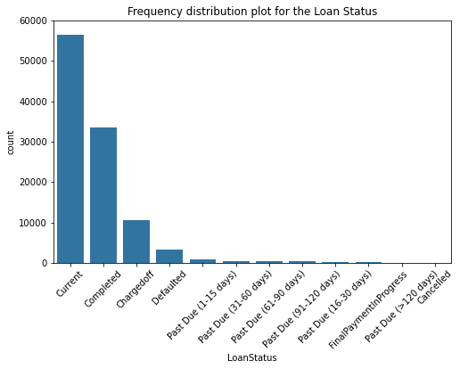

```python
#the LoanStatus frequency of the borrowers
plt.figure(figsize =[8, 5])
color = sb.color_palette()[0];
frequency = df1['LoanStatus'].value_counts().index;
sb.countplot(data = df1, x="LoanStatus", color=color, order = frequency);
plt.ylim(0, 60000);
plt.title("Frequency distribution plot for the Loan Status")
plt.xticks(rotation = 45);
```

### Observation

The plot above suggest that most of the clients have their loan status as current with a count of apploximately 55,000 thousand and it also show oly a few who have their loans past due.

### Question 2

#### What is the ListingCategory of the borrowers?

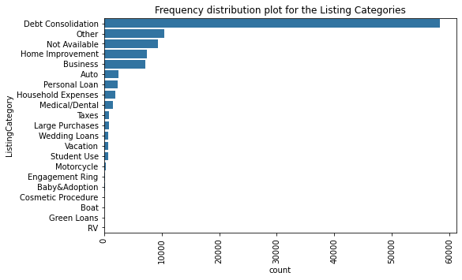

```python
#ListingCategory
plt.figure(figsize =[8, 5]);
color = sb.color_palette()[0];
frequency = df1['ListingCategory'].value_counts().index;
sb.countplot(data = df1, y="ListingCategory", color=color, order = frequency);
plt.title("Frequency distribution plot for the Listing Categories")
plt.xticks(rotation = 90);
```

### Question 3

#### What is the EmploymentStatus of the borrowers?

```python
EmploymentStatus_counts = df1['EmploymentStatus'].value_counts()
EmploymentStatus_counts
```

```
Employed         67321
Full-time        26342
Self-employed     6132
Other             3800
Part-time         1088
Not employed       834
Retired            795
Name: EmploymentStatus, dtype: int64
```

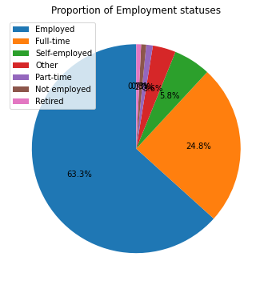

```python
#Employment Status
EmploymentStatus_counts = df1['EmploymentStatus'].value_counts();
# labels = ["Employed","Full-time","Self-employed","Other","Part-time","Not employed","Retired"]
plt.figure(figsize =(8, 6));
plt.pie(EmploymentStatus_counts, autopct="%1.1f%%", startangle=90);
plt.legend(labels = EmploymentStatus_counts.index);
plt.title("Proportion of Employment statuses");
plt.show();
```

### Observations

To get a clear frequency in the EmploymentStatus variable, I had to find the count of each value using the `value_counts()` function and later plotted a pie chart to show the distribution. The pie chart indicates that a 63.3% of the borrowers are employed and just a small percentage of them are retired.

### Question 4

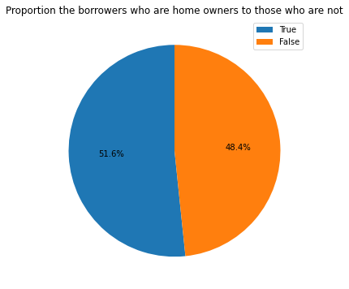

```python
#Is the borrower a home owner or not
Homeowner_counts = df1['IsBorrowerHomeowner'].value_counts()
plt.figure(figsize =(8, 6))
plt.pie(Homeowner_counts,autopct="%1.1f%%",  startangle=90)
plt.legend(labels = Homeowner_counts.index)
plt.title("Proportion the borrowers who are home owners to those who are not")
plt.show()
```

### Observations

The pie chart above shows the percentage of the borrowers who are home owners and those that are'nt. I can conclude that 51.6% of the borrowers are home owners and only 48.4% are not home owners.

### Question 5

#### What is the IncomeRange of the Loan borrowers?

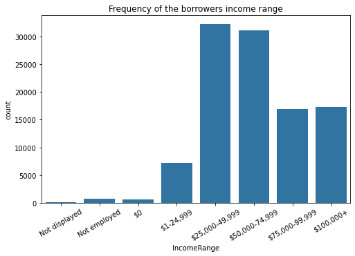

```python
#income range
# incomerangeorder = df1["IncomeRange"].value_counts().index
plt.figure(figsize =[8, 5]);
sb.countplot(data = df1, x='IncomeRange', color=color, order=income_range_cat);
plt.title("Frequency of the borrowers income range");
plt.xticks(rotation = 30);
```

### Observations

The distrbution above shows the frequency of the income range of the borrowers and $25,000 - $49,000 category had the highest frequency meaning that a large number of borrowers had an income range of $25,000 - $49,000 and just a few who chose not to display their income range.

### Question 6

What is the LoanOriginationYear of the Loan borrowed?

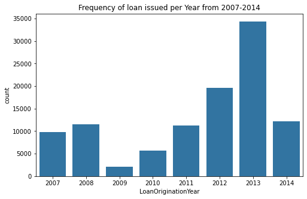

```python
#Loan origination year
# I am going creating another variable and store it at `LoanOriginationYear` variable
plt.figure(figsize =[8, 5]);
df1["LoanOriginationYear"] = df1["LoanOriginationDate"].dt.year;
plt.title("Frequency of loan issued per Year from 2007-2014");
sb.countplot(data=df1, x="LoanOriginationYear", color=color);
```

### Observations

The prosper loan dataset have a loan original date which i extracted the loan original year and stored in a `LoanOriginalYear` variable and used it to plot a frrequency distribution. The dstribution shows that more than 30,000 borrowers took their loans in the year 2013, and less than 5,000 borrowers took their loan in 2009 which has the least count.

## Bivariate Exploration

### Question 7

How does the borrowers income Range affect the loan original amount borrowed?

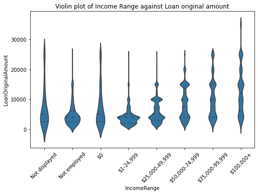

```python
# IR_count = [""]
plt.figure(figsize =[8, 5]);
sb.violinplot(data=df1, x="IncomeRange", y="LoanOriginalAmount",color=color, inner='quartile', order=income_range_cat);
plt.title("Violin plot of Income Range against Loan original amount");
plt.xticks(rotation=45);
```

### Observations

I looked at the relationship between IncomeRange and the LoanOriginalAmount using a violin plot. Each violin show the median,lower and upper quartile of the LoanOriginalAmount in every IncomeRange category. The 100,000+ have a greater interquartile range.

### Question 8

Should the borrowers consider the loan term when taking the loans?

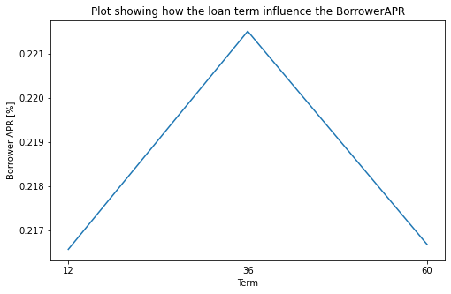

```python
plt.figure(figsize=[8,5])
plt.plot(df1.groupby('Term')['BorrowerAPR'].mean());
plt.xlabel('Term');
plt.ylabel('Borrower APR [%]');
plt.title("Plot showing how the loan term influence the BorrowerAPR");
plt.xticks([12,36,60]);
plt.show();
```

### Observations

Term and BorrowerAPR variables are among our features of focus and have been visialized as above. The plot shows that those who paid thier loan in a 36 month term bases were charged higher as shown by the high peak above 0.221% pa.

### Question 9

How does the Loan Status compare based on the Loan term?

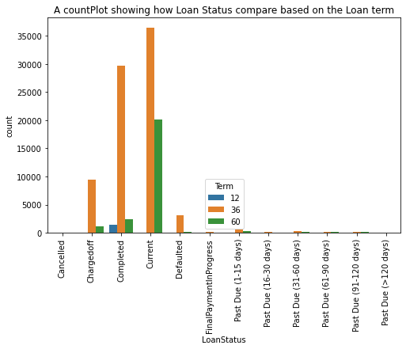

```python
plt.figure(figsize=[8,5]);
sb.countplot(data=df1, x='LoanStatus', hue='Term');
plt.title("A countPlot showing how Loan Status compare based on the Loan term");
plt.xticks(rotation = 90);
```

### Question 10

How does the Loan original amoount and the Borrower rate affect each other?

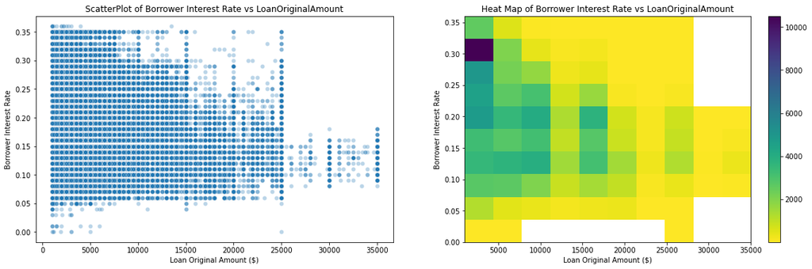

```python
plt.figure(figsize=[20,13])

plt.subplot(2,2,1)
sb.scatterplot(data=df1, y='BorrowerRate', x='LoanOriginalAmount', alpha=.3)
plt.ylabel('Borrower Interest Rate')
plt.xlabel('Loan Original Amount ($)')
plt.title('ScatterPlot of Borrower Interest Rate vs LoanOriginalAmount');

plt.subplot(2,2,2)
plt.hist2d(data=df1,  y='BorrowerRate', x='LoanOriginalAmount', cmap='viridis_r', cmin=0.8)
plt.ylabel('Borrower Interest Rate')
plt.xlabel('Loan Original Amount ($)')
plt.title('Heat Map of Borrower Interest Rate vs LoanOriginalAmount');
plt.colorbar();
```

### Question 11

How does the loan term affect the BorrowerAPR and the BorrowerRate?

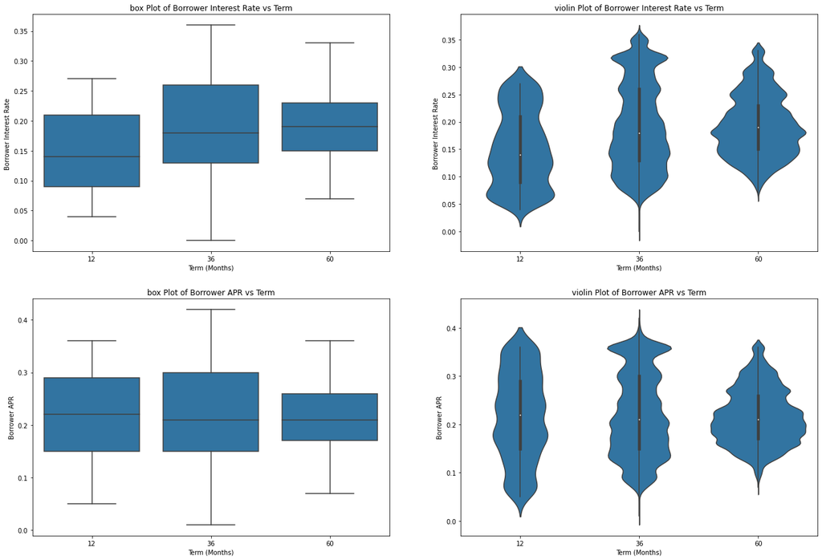

```python
plt.figure(figsize=[22,15])
plt.subplot(2,2,1)
sb.boxplot(data=df1, y='BorrowerRate', x='Term',color=sb.color_palette()[0])
plt.ylabel('Borrower Interest Rate ')
plt.xlabel('Term (Months)')
plt.title('box Plot of Borrower Interest Rate vs Term');

plt.subplot(2,2,2)
sb.violinplot(data=df1,  y='BorrowerRate', x='Term',color=sb.color_palette()[0])
plt.ylabel('Borrower Interest Rate')
plt.xlabel('Term (Months)')
plt.title('violin Plot of Borrower Interest Rate vs Term');

plt.subplot(2,2,3)
sb.boxplot(data=df1, y='BorrowerAPR', x='Term',color=sb.color_palette()[0])
plt.ylabel('Borrower APR')
plt.xlabel('Term (Months)')
plt.title('box Plot of Borrower APR vs Term');

plt.subplot(2,2,4)
sb.violinplot(data=df1,  y='BorrowerAPR', x='Term',color=sb.color_palette()[0])
plt.ylabel('Borrower APR')
plt.xlabel('Term (Months)')
plt.title('violin Plot of Borrower APR vs Term');
```

### Question 12

How does the Stated monthly income affect the borrower's LoanStatus?

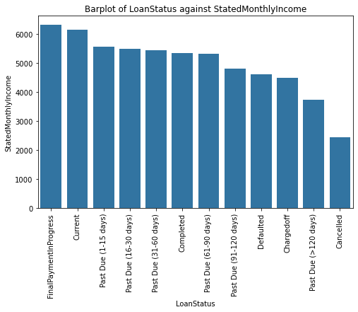

```python
plt.figure(figsize=[8,5])
color = sb.color_palette()[0];
plot_order = df1.groupby('LoanStatus')['StatedMonthlyIncome'].mean().sort_values(ascending=False).index.values

sb.barplot(data=df1, x='LoanStatus',  y='StatedMonthlyIncome',  ci=None,color=color, order=plot_order)
plt.title("Barplot of LoanStatus against StatedMonthlyIncome")
plt.xticks(rotation = 90);
```

### Observations

The plot above illustrates the relationship of `LoanStatus` to `StatedMonthlyIncome` and we can say that borrowers with the higher monthly income have their loan at the FinalPayment in progress. Those who have the least monthly income have their loans as cancelled due to various factors such as high interest rates which made it hard for them to pay the loans hence cancelling.

### Question 13

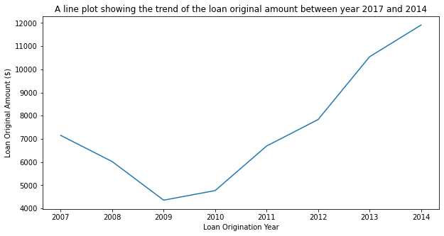

```python
#Line plot for the average loan original amount vs Loan Origination Year
plt.figure(figsize=[10,5])
plt.plot(df1.groupby('LoanOriginationYear')['LoanOriginalAmount'].mean())
plt.xlabel('Loan Origination Year')
plt.ylabel('Loan Original Amount ($)')
plt.title("A line plot showing the trend of the loan original amount between year 2017 and 2014")
plt.show();
```

### Observations

We wanted to see which year had the highest amount of loan borrowed by plotting a line gragh which shows that 2009 had the least loan amount issued of below $5,000 and since then, the rate at which the loan was issued increased over the years. This could be high cost of living which compelled people to borrow more.

### Talk about some of the relationships you observed in this part of the investigation. How did the feature(s) of interest vary with other features in the dataset?

> For the `BorrowerAPR`, a 36 months term is likely to have the highest interest rates paid as compared to other terms.

> For the `BorrowerRate`, Loan amount of less than 10,000 tend to have a higher interest rate and that of 25,000 and above have a relatively lower rates of bwteen 0.05 and 0.2.

> For the `LoanStatus`, a 36 months term was observed as the majority term in the Current, COmpleted, ChargedOff, Defaulted and all the past due categories as well.

> It is also observed that borrowers of 0 income range had access to higher sizes of loans than borrowers in the income range of `Not Employed` and 1-25,000 and also had access to same sizes of loans with those within the IncomeRange of 25,000-50,000. Borrower with the income range of 25,000-100,000+ had access to the highest sizes of loans.

> For the `LoanOriginalAmount` we see that 2009 recorded the least amount of loan acquired which later increased gradually over the following years rising form 4,000 to 12,000 in span of five years.

### Did you observe any interesting relationships between the other features (not the main feature(s) of interest)?

> 2009 have the least amount of loan issued.

> We also see that, borrowers who took a loan of 36 months term paid higher interest than of the 12 months and 60 months terms.

## Multivariate Exploration

### Question 14

How does the Loan original amount affect the loanStatus accross all income ranges?

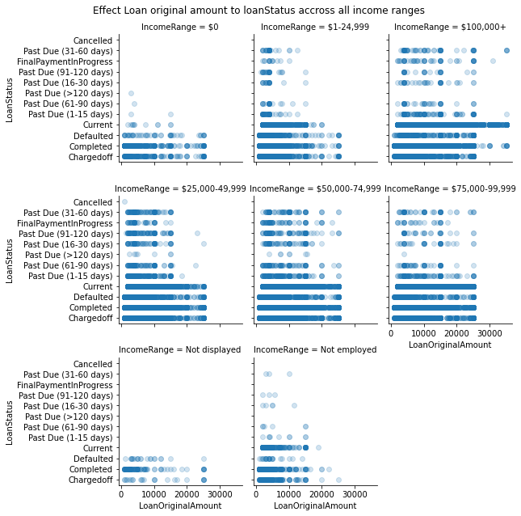

```python
def mult_var():
    pd_ver = pd.__version__.split(".")
    if (int(pd_ver[0]) > 0) or (int(pd_ver[1]) >= 21): # v0.21 or later
        vclasses = pd.api.types.CategoricalDtype(ordered = True, categories = income_range_cat)
        df1['IncomeRange'] = df1['IncomeRange'].astype(vclasses)
    else: # compatibility for v.20
        df1['IncomeRange'] = df1['IncomeRange'].astype('category', ordered = True, categories = income_range_cat);
  # plotting
g = sb.FacetGrid(data = df1, col = 'IncomeRange', height = 3, col_wrap = 3);
g.fig.suptitle("Effect Loan original amount to loanStatus accross all income ranges");
g.map(plt.scatter, 'LoanOriginalAmount', 'LoanStatus', alpha = 1/5);
# plt.title("Plot to show how Loan original amount affect the loanStatus accross all income ranges")
```

### Question 14

How does the Monthly loan payments compare with the loan Status accross the 3 loan terms?

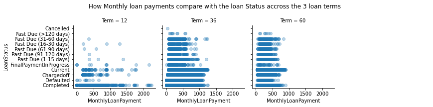

```python
plt.figure(figsize=[8,5])
g = sb.FacetGrid(data = df1, col = 'Term', col_wrap = 4);
g.fig.suptitle("How Monthly loan payments compare with the loan Status accross the 3 loan terms")
g.map(plt.scatter, 'MonthlyLoanPayment','LoanStatus', alpha=0.3);
g.add_legend();
# plt.title("Scatter plot showing how Monthly loan payments compare with the loan Status accross the 3 loan terms")
```

### Question 15

How does the Loan original amount influence the borrowerAPR over the 3 loan terms?

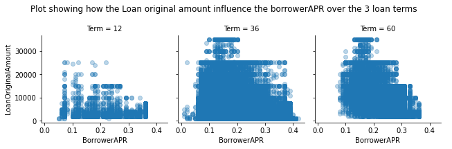

```python
axy = sb.FacetGrid(data = df1, col="Term", col_wrap = 3);
axy.fig.suptitle("Plot showing how the Loan original amount influence the borrowerAPR over the 3 loan terms");
axy.map(plt.scatter, "BorrowerAPR","LoanOriginalAmount", alpha=0.3);
axy.add_legend();
```

### Question 16

How does the loan original amount and the monthly loan payment related based on the employment status of the borrower?

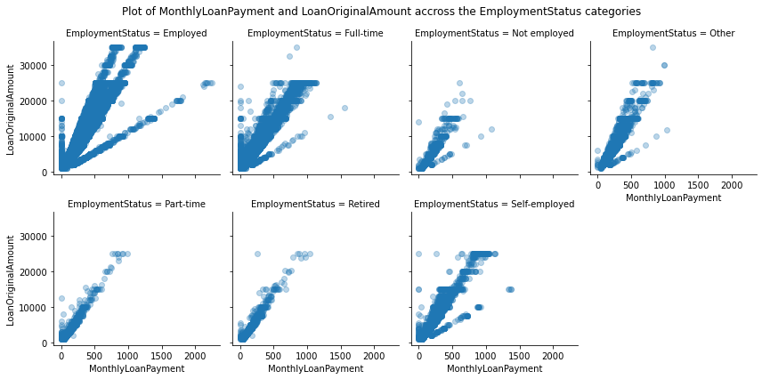

```python
ay = sb.FacetGrid(data=df1, col= "EmploymentStatus", col_wrap=4);
ay.fig.suptitle("Plot of MonthlyLoanPayment and LoanOriginalAmount accross the EmploymentStatus categories");
ay.map(plt.scatter, 'MonthlyLoanPayment', 'LoanOriginalAmount', alpha=.3);
# ay.add_legend()
```

### Observations

As observed from the plot above, the higher the loan original amount acquired, the higher the monthly payment of the loan accross all the employment status categories.

### Talk about some of the relationships you observed in this part of the investigation. Were there features that strengthened each other in terms of looking at your feature(s) of interest?

> It is observed that the higher the loan original amount acquired, the higher the monthly payment of the loan accross all the employment status categories.

## Conclusions

> The prosper loan dataset provided a very large amount of observations defined by 81 variables. I applied data wrangling and cleaning teachniques to make sure I am left with the data I need for my exploration. After all the wrangling and cleaning, I got 106,312 observations and 17 variables. I then added a new variable but extracting the year variable from the date making the tatol number of variables to be 18.

#### The main questions that guided the analysis of the dataset were as below

- What are the factors that affected the `BorrowerRate` and `Borrower interest rates`.
- How does the `monthly stated income` affect the loan status and the monthly loan payment.
- How does employment status affect the loan original amount.

#### monthly stated income vs Loan Status¶

Loans of borrowers with monthly income of 2,500 and below were cancelled which could be due to high amount of monthly loan payments. However,majority of borrowers with an income of above 5,000 had their loans at the final payment, some completed,some current and also some had their loans past due.

#### Eployment Status vs the loan original amount

It was observed that employed borrowers accessed higher loans sizes than the NotEmployed/part-time borrowers.